# Neural disjunctive normal form

## Neural disjunctive normal form

Basically it is about

- Neuro-Symbolic model, which has mixed discrete-continuous parameters.
- how to optimize the mixed discrete-continuous parameters.
- the general design principle here is to design an algorithm that is simple and general. Thus following the [bitter lesson](http://www.incompleteideas.net/IncIdeas/BitterLesson.html) and ultimately be more useful.

## A two-stage formulation that integrates “vertically”

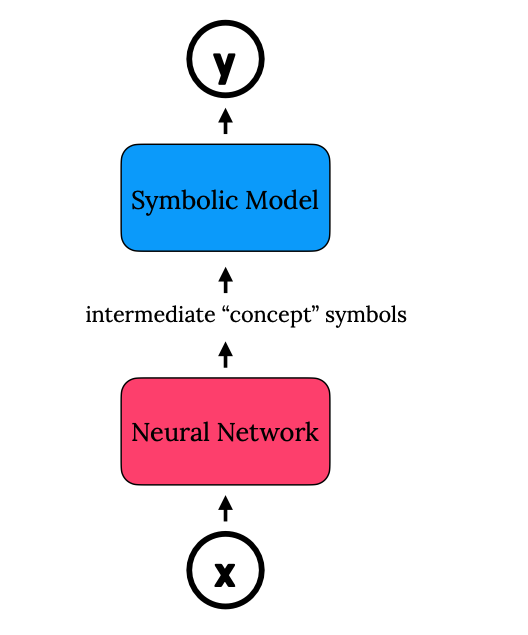

**Stage 1: the deep neural network**  
handles perception: extracting high-level concepts “symbols” from raw sensory data.  
**Stage 2: the symbolic model**  
handles reasoning: utilizes symbolic models to reason about the high-level concepts to make interpretable predictions. The choice of symbolic model to use depends on the task.

## For classiciation in propositional logic: Neural DNF

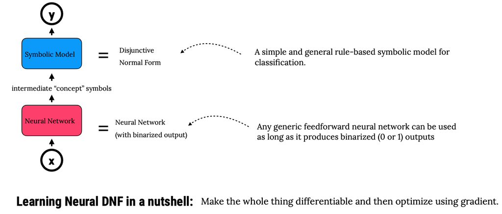

## Approach:

- **Step 1**: Make the model end-to-end differentiable
- **Step 2**: Use two optimizers for the continuous and discrete parameters. Use a SGD optimizer for the first stage neural network, develop a new optimizer for the discrete parameters of the symbolic part.

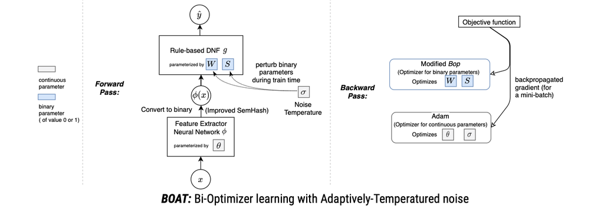

- the design principle here is to maximally retain the deep learning flavour (the end-to-end approach)

## Example: MNIST-sums-to-odd

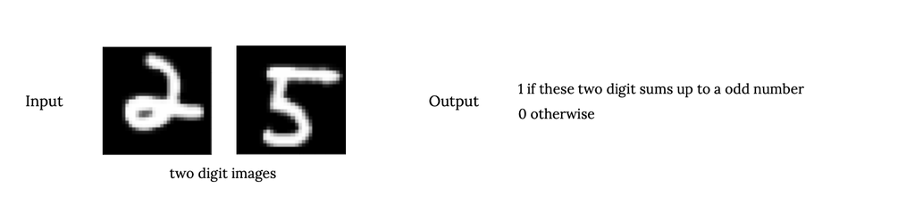

- **How would a human solve this problem?**
- perhaps a two stage computation.
  - determine for each of the two digits, whether it is odd or even.
  - make decision: two digit sum up to odd if one of the two digits is an even number and the other is an odd number, and otherwise it will sum to an even number.

## Applying Neural DNF

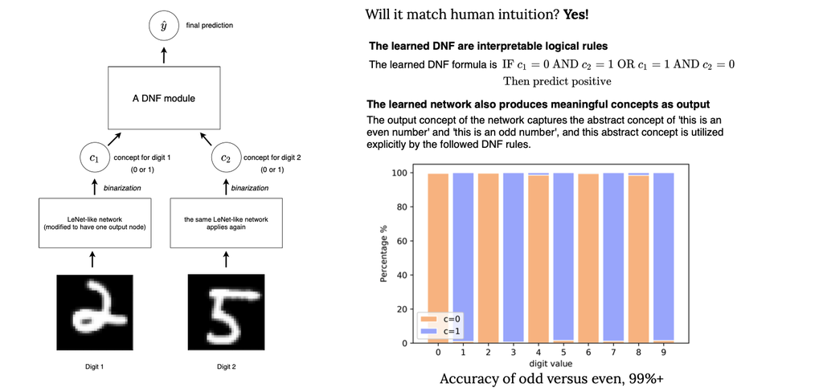

## Example 2: bird classification

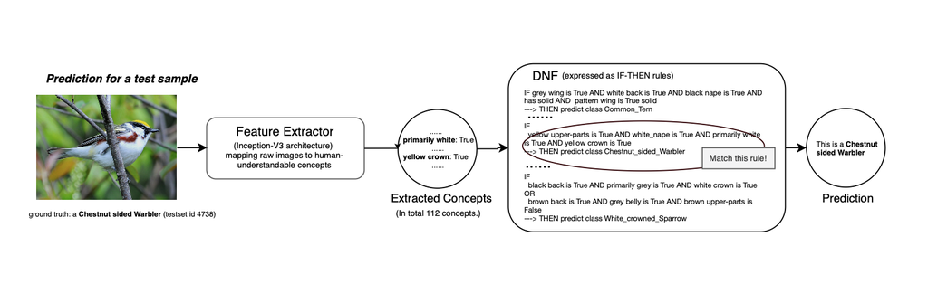

## Hybrid v.s. pure symbolic/deep model

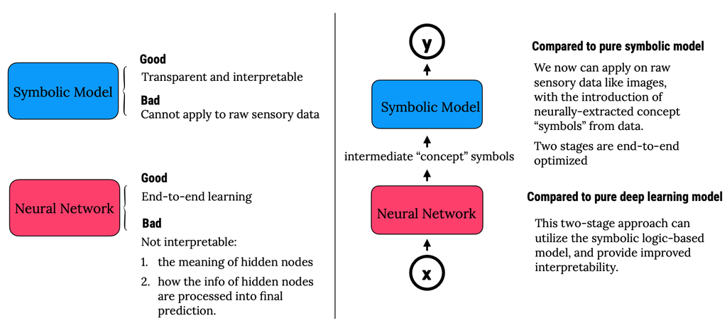